# Homework 1

CISM Introductory R Course

Due: Monday, March 27, 2017

This is homework assignment number 1. The assignment consists of creating an R script containing code for sections 3-5. You must email that script to joebrew@gmail.com before 23:59 on Monday, March 27, 2017.

If you run into any problems or have any questions, please email Joe.

## Section 1: Installation

Find a place with a good internet connection. We’re going to install some packages from the internet.

### Install RTools

Run the following code.

```r
version$minor
```

This tells you what *version* of R you have. Now, if you have Windows, go to this site:

https://cran.r-project.org/bin/windows/Rtools/

And download and install the `RtoolsXX.exe` file that corresponds to your version of R.

So far so good, right? Any problems, just email Joe.

### Install the “devtools” package

```r
install.packages('devtools')
```

If you run the above successfully, great! Keep going.

If you have problems, or get errors, email joebrew@gmail.com

### Install the “databrew” package

```r
library(devtools)
install_github('databrew/databrew', dependencies = TRUE, force = TRUE)
```

If the above gives you errors, then run the following:

```r
pkgs <- c("data.table", "devtools", "ggmap", "ggthemes",
        "gsheet", "knitr", "leaflet", "maptools", "raster", "RColorBrewer",
        "rgdal", "rgeos", "rmarkdown", "sp", "tidyr", "tidyverse",
        "tufte")
pkgs <- pkgs[!(pkgs %in% installed.packages()[, "Package"])]
pkgs <- sort(pkgs)
if (length(pkgs) == 0) {
    message("All packages already installed. No action being taken.")
} else {
    the_message <- paste0("Installing the following packages:\n",
        paste0("--- ", pkgs, collapse = "\n"))
    message(the_message)
    for (i in 1:length(pkgs)) {
        message("Installing ", pkgs[i])
        install.packages(pkgs[i])
    }
}
library(devtools)
install_github('databrew/databrew')
```

### Install some other packages

This could take a while, because we’re about to install *a lot* of packages. Make sure you have a good internet connection. While things are downloading, go have a drink.

```r
library(databrew)
install_packages()
```

Done, right? Wrong! There is one more package to install:

```r
library(devtools)
install_github('joebrew/cism')
```

Did you make it to here? Great! Now you have a lot of new, interesting, packages ready to use in R. These are:

```
cism
databrew
data.table
devtools
ggmap
ggthemes
gsheet
knitr
leaflet
maptools
raster
RColorBrewer
rgdal
rgeos
rmarkdown
sp
tidyr
tidyverse
tufte
```

You don’t know what these are for? That’s okay - we’ll learn more about each one as we go.

## Section 2: Getting new data

We’re going to get some new data to analyze. This data is like the census data. However, it has been “anonymized” (locations have been jittered and mix-matched randomly, answers have been permutated, etc.).

### Two ways to get data

You can download this data at www.databrew.cc/census.csv. Then, once you have it downloaded, you can read it in (just like we did in class).

```r
census <- read.csv('C:/Users/Amone/Desktop/census.csv')
```

Or, you can load it directly in R by just running the following.

```r
census <- databrew::census
```

Tudo bem? Great! You’ve now got some data to explore.

## Section 3: Exploration

Now begins the “real work”. Everything before here was just preparation. You’ll need to send the code for sections 3-5 to Joe.

Answer the following questions. For an answer to be correct, you must both have the correct answer *and the correct code*.

1. How many rows are in the data? (hint: use `nrow`)
2. How many columns are in the data? (hint: use `ncol`)
3. What are the names of the columns? (hint: use `colnames`)

That wasn’t so bad, was it? Now we knoow about the *form* of our data. It’s time to explore the *content*.

4. Create an object called `sex_table` like this:

```r
sex_table <- table(census$sex)
```

5. How many males are in our data?
6. What *percentage* of our observations are female? You can do this by running `prop.table(sex_table)` or by running `sex_table / nrow(census)`
7. What is the maximum age in our data?
8. What is the minimum age in our data?
9. Create a histogram of the ages of the people in our data. Make it pretty (ie, title, axis labels, etc.).
10. Create a barplot of the `sex_table` object you created earlier. Make it pretty.

## Section 4: More exploration

You’re doing great! Now it’s time to do even greater!

1. Use the `table` function to create an object called `floor_table` which tabulates the floor material of all the houses in our data.
2. How many of our houses have cement floors?
3. What percentage of our houses have cement floors?
4. Create another table called `bike_table` with information about whether people have bikes or not.
5. Create a barplot of `bike_table`. Make it pretty.
6. Create a new variable called “tv_and_car” like this:

```r
census$tv_and_car <-
  ifelse(census$tv == 'yes' &
           census$car == 'yes',
         'Has TV and car',
         'Does not have TV and car')
```

7. Use `table` to see how many people have both a TV and a car?
8. Use `prop.table` to see what percentage of people have both a TV and a car.
9. Create a *two variable* table (a “cross-table”) called `xt` using the `tv_and_car` variable and the `celular` variable (hint, use the `table` function, but just put a comma between the variables)
10. Are there any people that have a TV and a car, but don’t have a cell phone?

## Section 5: Mapping

Let’s make some maps!

1. We’re going to make a map of Mozambique. This map is easily available in the `cism` package. It’s called `moz0`.

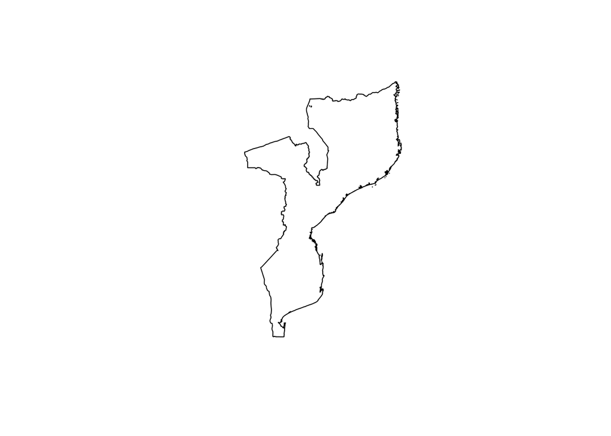

```r
library(cism)
library(sp)
plot(moz0)
```

The `0` means that it is at the national level. You can also make a map at the province level (`moz1`), the district level (`moz2`) or the sub-district level (`moz3`). (But you don’t have to do this yet)

```r
cism_map(lng = census$longitude,
         lat = census$latitude)
```

[output not shown]

9. See the documentation on `cism_map` and how to use it (hint, use a “?”).
10. Make an interactive map using the `cism_map_interactive` function. If you do this right, it should look like this:

[interactive chart not shown]

You’re done! Congratulations! Email your R code and answers to Joe: joebrew@gmail.com